# IV — Motivation

Natasha Kang

Xiamen University, Chow Institute

May, 2026

## Roadmap

1. When conditioning fails: three sources of endogeneity
2. Measurement error and attenuation bias
3. The IV idea: relevance and exogeneity
4. Identifying the effect: the Wald ratio
5. What does IV estimate? LATE

## The Story So Far

- Parts II–III: OLS identifies causal effects when we can **condition on the right controls**.
- Lect4c: DAGs help us choose controls. But what if…
- The confounder is **unobservable** (ability, motivation, talent)?
- No set of observed controls can close the back-door path.
- We need a fundamentally different strategy.

## Three Sources of Endogeneity

All three violate the zero conditional mean assumption $E[u \mid X] \neq 0$:

| Source | Description | Example |
| --- | --- | --- |
| **Omitted variables** | Unobserved confounder in $u$ | Ability in wage equation |
| **Simultaneity** | $X$ and $Y$ determined jointly | Price and quantity |
| **Measurement error** | Observed $X$ differs from true $X^*$ | Self-reported schooling |

In all three cases, OLS is **inconsistent** — more data does not help.

## Simultaneity

**Goal**: estimate the demand curve — how does quantity demanded respond to price?

$$Q^d = \alpha_0 + \alpha_1 P + U^d$$

But price is not set exogenously — it is determined by the interaction of supply and demand:

$$Q^s = \gamma_0 + \gamma_1 P + U^s$$

In equilibrium, $Q^d = Q^s$ and $P$ adjusts to clear the market.

The observed price $P$ reflects **both** demand shocks ($U^d$) and supply shocks ($U^s$).

## Simultaneity — The Naive OLS

Suppose we collect equilibrium $(P, Q)$ data and regress $Q$ on $P$:

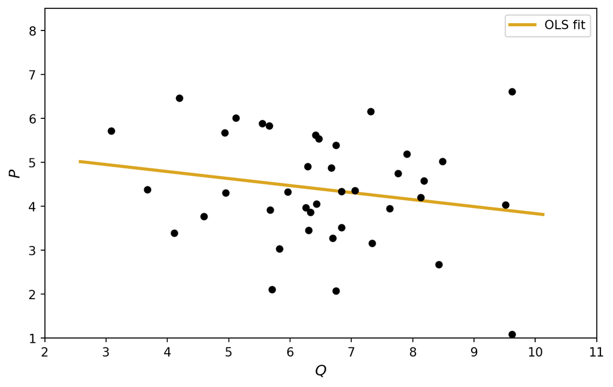

The OLS slope is neither the demand slope nor the supply slope. Why?

## Simultaneity — Identification

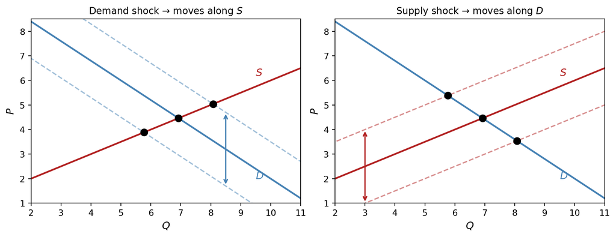

To estimate the **demand curve**, we need a variable that shifts only supply (e.g., input costs, weather). Conversely, to estimate the **supply curve**, we need one that shifts only demand (e.g., income, tastes). This is the **instrumental variables** idea — and historically, simultaneity was its original motivation (Wright, 1928).

## Measurement Error

A different source of endogeneity — the regressor itself is measured with error.

| Source | Example |
| --- | --- |
| **Self-reporting** | Individuals misreport income, schooling, hours worked |
| **Proxy variables** | IQ score as proxy for ability |
| **Data processing** | Rounding, aggregation, privacy masking |

**Canonical case**: self-reported schooling. Wages respond to *true* schooling $E^*$, but the Census records the *reported* value $E = E^* + V$. People misremember, round, or inflate.

## Classical vs Non-Classical ME

- **Classical ME**: error is random, uncorrelated with the truth. $\Rightarrow$ predictable bias toward zero (**attenuation**).
- **Non-classical ME**: error is systematic or correlated with the truth (e.g., high earners underreport income). $\Rightarrow$ bias direction depends on the structure.

We derive the classical case next.

## Classical Measurement Error — Setup

Suppose the true model is:

$$Y = \beta_0 + \beta_1 E^* + U, \quad E[U \mid E^*] = 0$$

But we observe $E = E^* + V$ instead of $E^*$.

**Classical measurement error assumptions**:

1. $E[V] = 0$
2. $\text{Cov}(V, E^*) = 0$ — error is uncorrelated with the truth
3. $\text{Cov}(V, U) = 0$ — error is uncorrelated with the structural error

## OLS with Measurement Error

Substituting $E^* = E - V$ into the true model:

$$Y = \beta_0 + \beta_1 E + (U - \beta_1 V)$$

Define the composite error $W = U - \beta_1 V$. Then:

$$\text{Cov}(E, W) = \text{Cov}(E^* + V, \; U - \beta_1 V) = -\beta_1 \sigma_V^2 \neq 0$$

- The regressor $E$ is correlated with the composite error $W$.
- ZCM fails, so OLS is **inconsistent**.

## Attenuation Bias — Derivation

$$\text{plim}\, \hat\beta_1 = \frac{\text{Cov}(E, Y)}{\text{Var}(E)}$$

The numerator:

$$\text{Cov}(E, Y) = \text{Cov}(E^* + V, \; \beta_0 + \beta_1 E^* + U) = \beta_1 \sigma_{E^*}^2$$

The denominator:

$$\text{Var}(E) = \text{Var}(E^* + V) = \sigma_{E^*}^2 + \sigma_V^2$$

Therefore:

$$\text{plim}\, \hat\beta_1 = \beta_1 \cdot \underbrace{\frac{\sigma_{E^*}^2}{\sigma_{E^*}^2 + \sigma_V^2}}_{\lambda}$$

## The Attenuation Factor

$$\lambda = \frac{\sigma_{E^*}^2}{\sigma_{E^*}^2 + \sigma_V^2}, \quad 0 < \lambda < 1$$

- $\lambda$ is a **signal-to-total-variance ratio**.
- $\hat\beta_1$ is biased **toward zero** — this is **attenuation bias**.
- More noise ($\sigma_V^2 \uparrow$) $\Rightarrow$ more attenuation ($\lambda \downarrow$).

**Schooling**: if half the variance in reported schooling is noise ($\sigma_V^2 = \sigma_{E^*}^2$), then $\lambda = 1/2$ — OLS recovers only half of $\beta_1$.

## What About Measurement Error in $Y$?

Suppose instead $Y$ is measured with error: $\tilde{Y} = Y + \eta$, with $E[\eta] = 0$, $\text{Cov}(\eta, E) = 0$.

$$\tilde{Y} = \beta_0 + \beta_1 E + (U + \eta)$$

The composite error $(U + \eta)$ is still uncorrelated with $E$. ZCM holds.

- OLS is **consistent** — the slope is unbiased.
- But $\text{Var}(U + \eta) > \text{Var}(U)$: larger error variance $\Rightarrow$ less precision, wider confidence intervals.

**Bottom line**: ME in the regressor biases the slope. ME in $Y$ only inflates the variance.

## Bridge to IV

All three sources of endogeneity share the same structure: $\text{Cov}(X, u) \neq 0$, and OLS is **inconsistent** — more data does not help.

**The common solution**: find a variable $Z$ that is:

1. Correlated with $X$ (**relevance**)
2. Uncorrelated with the error $u$ (**exogeneity**)

Such a variable $Z$ is called an **instrumental variable** (or **instrument**).

- **Omitted variables**: a variable that shifts $X$ via a channel unrelated to the confounder.
- **Simultaneity**: a supply shifter (input costs, weather) is an instrument for price.
- **Measurement error**: a variable correlated with the true $X^*$, not with the noise $V$.

## IV Conditions

We seek a variable $Z$ (the **instrument**) satisfying:

**1. Relevance**: $\text{Cov}(Z, X) \neq 0$

- $Z$ is correlated with the endogenous regressor $X$.
- **Testable** — we can check this in the data (more in 5b).

**2. Exogeneity**: $\text{Cov}(Z, u) = 0$

- $Z$ is uncorrelated with the error.
- **Partially testable** — overidentification tests (more in 5b), but primarily argued from theory/institutional knowledge.

## DAG Representation

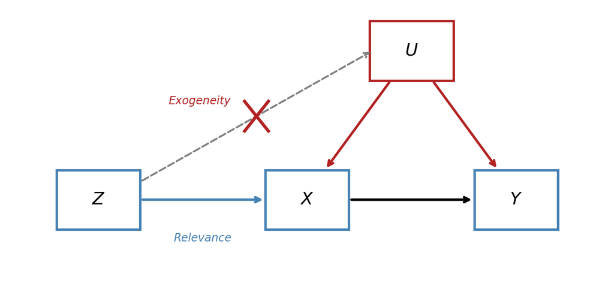

## Example: Vietnam Draft Lottery (Angrist 1990)

**Background**: During the Vietnam War, the U.S. drafted young men into the military. The pre-1969 Selective Service System granted deferments — most prominently for college enrollment — which fell disproportionately on the less-educated and was widely seen as unfair.

**The lottery (1970–72)**: To equalize exposure, draft priority was assigned by **random lottery on date of birth** — capsules drawn live on national TV. Each date received a **random sequence number (RSN)** from 1 to 365; low numbers were called first. For the 1950 cohort, $\text{RSN} \leq 195$ meant **draft-eligible**.

**Question**: What is the causal effect of military service on later civilian earnings?

- $Y$: civilian earnings in 1981 (10 years after)
- $D$: Vietnam-era veteran status (binary)
- $Z$: lottery eligibility ($\text{RSN} \leq 195$, binary)

## Why the Lottery as Instrument?

**Relevance**: Eligibility raises the probability of veteran status.

- Eligible: 35% became veterans
- Non-eligible: 19% became veterans
- Effect of $Z$ on $D$: ~16 percentage points

**Exogeneity**: RSN is assigned by date of birth — *literally random*. No selection on ability, motivation, or family background.

**Why we still need IV**: not everyone eligible served (deferments, failed physicals); some non-eligible served voluntarily. So $Z \neq D$ — the lottery shifts but does not determine veteran status.

## IV Intuition

OLS comparing veterans to non-veterans uses **all** variation in $D$ — including the part driven by self-selection.

IV uses **only the variation in $D$ driven by the lottery** — the random part.

- Since $Z$ is random, that variation is exogenous *by design*.
- The price: most of the variation in $D$ is discarded (only ~16 pp is moved by $Z$), so IV is less efficient.

## Three Natural Estimators

**1. ITT** (Intent-to-Treat): $\widehat{\text{ITT}} = \bar Y_{Z=1} - \bar Y_{Z=0}$

Effect of *being eligible* — clean, but not the effect of *serving*.

**2. As-Treated**: $\hat\beta^{OLS} = \bar Y_{D=1} - \bar Y_{D=0}$

Effect of *being a veteran* — but biased: $D$ is self-selected on unobservables.

**3. IV / Wald**: $\hat\beta^{IV} = \dfrac{\bar Y_{Z=1} - \bar Y_{Z=0}}{\bar D_{Z=1} - \bar D_{Z=0}}$

ITT scaled by the effect of $Z$ on $D$. Why is this the right thing to compute?

## IV — The Wald Ratio

Start from $Y = \beta_0 + \beta_1 D + U$ with exogeneity $\text{Cov}(Z, U) = 0$.

Take expectations conditional on $Z$:

$$E[Y \mid Z = z] = \beta_0 + \beta_1 E[D \mid Z = z] + E[U \mid Z = z]$$

Differencing $Z=1$ and $Z=0$, with $E[U \mid Z=1] = E[U \mid Z=0]$ by exogeneity:

$$E[Y \mid Z{=}1] - E[Y \mid Z{=}0] = \beta_1 \big(E[D \mid Z{=}1] - E[D \mid Z{=}0]\big)$$

$$\beta_1 = \frac{E[Y \mid Z{=}1] - E[Y \mid Z{=}0]}{E[D \mid Z{=}1] - E[D \mid Z{=}0]} \quad \text{(Wald ratio)}$$

## Angrist Numbers

White men born 1950, 1981 earnings (MHE Table 4.1.3):

| Quantity | Estimate | SE |
| --- | --- | --- |
| Mean 1981 earnings | $16,461 | — |
| $\bar Y_{Z=1} - \bar Y_{Z=0}$ | -$435.8 | 210.5 |
| $\bar D_{Z=1} - \bar D_{Z=0}$ | 0.159 | 0.040 |
| **Wald** | **-$2,741** | **1,324** |

- Wald estimate is ~17% of mean civilian earnings.

## What Does IV Estimate?

The Wald ratio identifies $\beta_1$ — a regression coefficient. But what **causal quantity** does $\beta_1$ correspond to? Under what assumptions?

- **RCT case (Lecture 1)**: $D \perp\!\!\!\perp (Y(0), Y(1)) \Rightarrow \beta_1 = E[Y(1) - Y(0)] = \text{ATE}$.
- **IV case**: $D$ is endogenous — so $\beta_1$ is **not** the ATE.

**Preview**: IV identifies the ATE for a specific subpopulation — the **compliers** (units whose treatment status is moved by $Z$). This is the **Local Average Treatment Effect (LATE)**.

To derive this, we need potential outcomes for the **treatment** as well as $Y$.

## Potential Outcomes in IV

In an IV setting, both $D$ and $Y$ have potential values:

**Potential treatment**: $D_i(z)$ = the treatment unit $i$ would take if $Z = z$.

Captures how $Z$ moves $D$ for each individual.

**Potential outcome**: $Y_i(z, d)$ = the outcome unit $i$ would have if $Z = z$ and $D = d$.

The two arguments allow $Z$ to enter $Y$ both through $D$ and directly. For IV to be valid, $Z$ must enter **only through $D$**: $Y_i(z, d) = Y_i(d)$ — the **exclusion restriction**.

The observed pair $(D_i, Y_i)$ corresponds to the realized $Z_i$.

## Compliance Types

Each unit’s $(D_i(0), D_i(1))$ classifies how it responds to $Z$:

| Type | $D(0)$ | $D(1)$ | Lottery analog |
| --- | --- | --- | --- |
| **Complier** | 0 | 1 | Drafted; would not have served otherwise |
| **Always-taker** | 1 | 1 | Volunteer; serves regardless of lottery |
| **Never-taker** | 0 | 0 | Deferred or disqualified |
| **Defier** | 1 | 0 | Opposite (no natural analog here) |

- Types are **latent**: we observe $D_i$, not $(D_i(0), D_i(1))$ separately.
- Only **compliers** respond to $Z$ — always-takers and never-takers are unmoved by the instrument.

## LATE Assumptions

1. **Exogeneity** (structural — on the counterfactual DGP):
   - **Independence**: $Z \perp\!\!\!\perp (Y(z, d), D(z))$ for all $z, d$. *Lottery*: guaranteed by randomization.
   - **Exclusion**: $Y_i(z, d) = Y_i(d)$ — no direct $Z \to Y$ channel. *Lottery*: violated if draft-eligible ($Z=1$) men enroll in college to avoid serving, shifting $Y$ through schooling rather than $D$.

   These structural restrictions **imply** the IV moment condition $\text{Cov}(Z, U) = 0$.
2. **Relevance**: $P(D=1 \mid Z=1) \neq P(D=1 \mid Z=0)$.
3. **Monotonicity**: $D(1) \geq D(0)$ for all units — no defiers.

## LATE — Statement

**Theorem** (Imbens & Angrist, 1994): Under Exogeneity + Relevance + Monotonicity,

$$\frac{E[Y \mid Z=1] - E[Y \mid Z=0]}{E[D \mid Z=1] - E[D \mid Z=0]} = E[Y(1) - Y(0) \mid D(1) > D(0)]$$

- **LHS**: the IV estimand for binary $Z$ (the Wald ratio).
- **RHS**: the **Local Average Treatment Effect (LATE)** — the ATE among compliers, i.e., units with $D(1) > D(0)$.

LATE is the ATE for a *specific subpopulation* — those whose treatment is moved by the instrument — not the population ATE nor the ATT.

## LATE — Proof Sketch (Numerator)

Three types by monotonicity: $C, A, N$. Decompose:

$$E[Y \mid Z=z] = \sum_{T \in \{C, A, N\}} P(T)\, E[Y \mid Z=z, T]$$

- **$A$** ($D=1$): $E[Y \mid Z=z, A] \underset{\text{excl.}}{=} E[Y(1) \mid Z=z, A] \underset{\text{indep.}}{=} E[Y(1) \mid A]$.
- **$N$** ($D=0$): same logic → $E[Y(0) \mid N]$.
- **$C$** ($D=Z$): $E[Y \mid Z=z, C] \underset{\text{excl.}}{=} E[Y(z) \mid Z=z, C] \underset{\text{indep.}}{=} E[Y(z) \mid C]$.

$$E[Y \mid Z=1] - E[Y \mid Z=0] = P(C) \cdot E[Y(1) - Y(0) \mid C]$$

## LATE — Proof Sketch (Denominator and Ratio)

**Denominator**: same type decomposition applied to $D$:

- **$A$**: $D=1$ always → contributes $P(A)$ under both $z$, cancels.
- **$N$**: $D=0$ always → contributes $0$, cancels.
- **$C$**: $D=1$ when $Z=1$, $D=0$ when $Z=0$ → contributes $P(C)$.

$$E[D \mid Z=1] - E[D \mid Z=0] = P(C)$$

**Ratio**:

$$\frac{P(C) \cdot E[Y(1) - Y(0) \mid C]}{P(C)} = E[Y(1) - Y(0) \mid C] = \text{LATE} \qquad \square$$

## LATE — Intuition

- Only **compliers** change their treatment status in response to $Z$.
- They generate **all** the identifying variation.
- Always-takers and never-takers are unaffected by $Z$, so they contribute nothing.

LATE is a **local** effect: it applies to the complier subpopulation, not the full population.

## LATE — External Validity

Different instruments move different compliers $\Rightarrow$ potentially different LATEs.

- **External validity**: LATE does not generalize unless compliers are representative.
- **Policy relevance**: matches universal (ATE) or targeted (ATT) policies only when compliers coincide with the target group.
- **Cross-study**: different instruments for the same treatment can give different LATEs.

## Question

When is LATE = ATE?

Think about what property of individual treatment effects $Y_i(1) - Y_i(0)$ would make the “complier-specific” distinction irrelevant.

## LATE — Beyond the Binary Case

The LATE theorem is for binary $Z$ and binary $D$. In practice:

- **Non-binary $D$** (e.g., years of schooling): IV identifies a weighted average of effects along the treatment ladder.
- **Non-binary $Z$** (e.g., a multi-valued instrument): IV identifies a weighted average of pairwise LATEs.

## LATE — Angrist Revisited

**Who are the compliers in Angrist (1990)?**

- Men whose veteran status is shifted by the lottery — they would serve if drafted, but not voluntarily.
- Pulled into service by a low draft number.
- **Always-takers**: volunteers — would serve regardless of the lottery.
- **Never-takers**: deferred or disqualified — would not serve regardless.
- **Compliers**: would prefer civilian life but accepted the draft.
- LATE $\approx$ -17% of earnings is the effect on **compliers** — men with relatively better civilian alternatives.
- The ATE (averaged over volunteers + compliers) is likely smaller in magnitude — volunteers self-selected into service, so it was (in expectation) beneficial for them.

## Threats to the Story

The Wald ratio identifies $\beta_1$ only under **exogeneity**: $\text{Cov}(Z, U) = 0$. We argued this from random assignment.

**But random $Z$ alone is not enough.** If $Z$ shifts $Y$ through channels other than $D$, those channels live in $U$ — and $\text{Cov}(Z, U) \neq 0$ even when $Z$ is random.

**Lottery responses** (men with low numbers had months to act):

- Enrolled in college for student deferments (II-S).
- Volunteered preemptively to choose their branch.
- Marriage / dependents → hardship deferments.

These shift schooling, family timing, occupation — affecting earnings without going through veteran status.

So the IV may be biased even though $Z$ was randomly assigned. **Random assignment is necessary for exogeneity, not sufficient.**

## Sanity Checks (Angrist 1990)

What can we check, given these threats?

**Pre-service placebo**: if $Z$ is truly random, it shouldn’t predict outcomes from *before* service. Computing $\bar Y_{Z=1} - \bar Y_{Z=0}$ on **1969 earnings** (pre-lottery): -$2 (SE 34.5) — statistically zero. ✓ Independence is empirically supported.

**Schooling response** (Angrist & Krueger 1995): the lottery raised completed schooling by ~0.1 extra years on average. The exclusion violation through schooling exists but is small in magnitude.

**Stability**: Angrist’s IV estimates are similar across race subgroups, birth cohorts (1950–53), and outcome years (1981–84).

None of these *prove* exclusion. They make the identification more credible.

## Summary

When OLS fails, an instrument $Z$ that is **relevant** (shifts $X$) and **exogenous** (uncorrelated with $U$) identifies $\beta_1$ via the Wald ratio.

**Causal interpretation (LATE)**: with binary $Z, D$ + monotonicity, the Wald ratio identifies the average effect on **compliers** — those moved by $Z$. Not the ATE.

- LATE is local: applies only to compliers; different instruments give different LATEs.
- Beyond binary $Z$ or $D$: IV identifies a weighted average of effects.

**Exogeneity is the binding assumption** — argued from theory, not testable in the just-identified case. Even random assignment doesn’t make it free.

## What’s Next

**Lecture 5b — IV Estimation**:

- The IV estimator: sample analog and consistency
- 2SLS: multiple instruments and controls
- Diagnostics: weak instruments, overidentification, endogeneity test
- Applications